# Ejemplos de probabilidad Avanzados

## Paradoja ¿niño o niña?

- Una mujer tiene 2 bebes donde el mayor es varón.
- Una mujer tiene 2 bebes donde uno de ellos es varón.

Hay una sutileza gramatical que en términos de probabilidades representa información adicional, esto en el ámbito de las probabilidades va a representar un cambio en el conteo de los eventos.

¿Cual es la probabilidad de que esta mujer tenga 2 hijos varones? Esto considerando las 2 situaciones:

- Una mujer tiene 2 bebes donde el mayor es varón.
- Una mujer tiene 2 bebes donde uno de ellos es varón.

El ejercicio consiste en darnos cuenta que la cantidad de información en ambas situaciones es diferente y por supuesto para el calculo de probabilidades de este ejercicio que parece sencillo debemos calcular el espacio muestral, donde dibujaremos una matriz.

- Eje x: Posibles géneros de hijo 1
- Eje y: Posibles géneros de hijo 2

Entonces lo que voy a tener es:

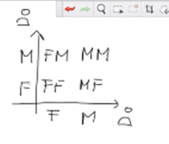

Donde:

- M: Masculino
- F: Femenino

Lo primero que debemos hacer es algunas preguntas:

- ¿Cual es la probabilidad de que ambos sean varones? $$p(MM)=\frac {\text{numero de eventos exitosos}}{\text{eventos totales}}=\frac 1 4$$ En resumen tenemos que la probabilidad de que el evento suceda es de $\frac 1 4$ sin ninguna condición previa.

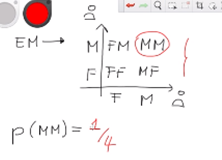

  Es decir esta situación no pertenece a ninguno de los casos enumerados.

¿Qué sucede si ahora decido imponer las condiciones? como esta:

- Una mujer tiene 2 bebes donde el mayor es un varón. ¿Cual es la probabilidad de que ambos sean varones sabiendo que el mayor es varón? $p(MM|mayor=\text{varón})$. Aquí es donde viene la paradoja. Entonces supongamos que el mayor sera el hijo 1, es decir el del eje x. Haciendo esto solo restrinjo los valores a 2 y de esa manera, solo existe un evento que resultaría exitoso (MM).

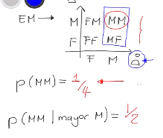

  Entonces la probabilidad de que ambos sean varones es de $\frac 1 2. Entonces esto funciona para la situación 1, pero si miramos la situación 2, la sutileza gramatical *Uno de ellos es varón* implica que realmente no se cual de ellos 2 es.  
  Esto si representa un cambio en la información, así que hagamos otro diagrama.
- Una mujer tiene 2 bebes donde uno de ellos es varón. De esta manera vemos que la paradoja consiste en la sutileza gramatical, y eso representa restricciones diferentes sobre el numero de estados posibles dentro del espacio muestral del problema, calculemos la probabilidad para esta 2da pregunta

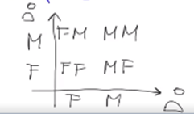

El texto anterior en el que la frase *Uno de ellos es varón implica 3 estados*

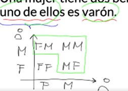

Entonces ahora calculemos la probabilidad de que los 2 sean varón sabiendo que alguno de ellos esa varón $p(MM|\text {alguno M})$
Entonces obtenemos lo siguiente $$p(MM|\text {alguno M})=\frac 1 3$$

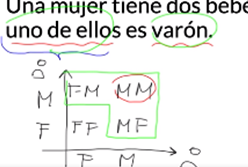

Entonces podemos ver que ambas probabilidades son diferentes a pesar de que ambas situaciones sonaban igual y la razón es: la cantidad de información contenida en las 2 frases debido a la sutileza gramatical es diferente y esto determina entonces resultados diferentes de probabilidad.

## El problema de Monthy Hall

Esta paradoja puede compararse a la de un show de Monthy Hall:

El ejercicio consistía que el siempre estaba con un participante, el cual tenía al frente 3 opciones de puertas.  
La idea del show es que el participante debía escoger una de las 3 puertas, ya que detrás de una de ellas iba a encontrar un premio y detrás de las otras 2 no había nada o un castigo, normalmente había una cabra y el premio era un automóvil, un viaje o lo que sea.

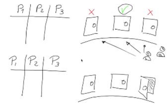

Entonces la idea era

- El presentador le pide al participante que escogiera una puerta, la escoge y preguntamos ¿cual es la probabilidad de que escogiera la puerta correcta?  
  Dibujemos el espacio muestral, cuando el participante escoge sin ninguna información adicional

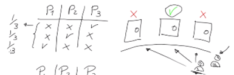

  Para el todas las opciones son igualmente probables. Por lo tanto para que el encuentre el premio la probabilidad es $\frac 1 3$

Entonces así era el problema tal cual, el truco del show consistía en que el participante escogía una puerta, después el presentador llegaba y abría una de las puertas, obviamente el presentador escogía una puerta sin recompensa.

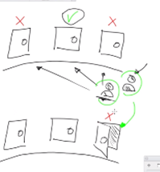

Entonces ese era el punto de información adicional. Después el participante sabía la información, y el presentador le preguntaba ¿usted se sostiene sobre la elección que hizo?.

Ahora pues decimos ¿cual es la probabilidad para saber en que evento puede lograr el premio?

Entonces desglosemos la elección. Imaginemos que hemos escogido la puerta 1 y el presentador abre la puerta 3, con lo cual esta acción reduce el mapa muestral, y nos queda solo 2 opciones en las que la puerta 3 no tiene el premio. De acuerdo a ello podemos calcular nuevamente la probabilidad de si escogemos alguna de las 2 puertas restantes, entonces podemos decir que solo tenemos 2 opciones y que la probabilidad es de $\frac 1 2$ por el hecho de que ambas situaciones son igualmente probables, entonces da igual cambiar la respuesta.

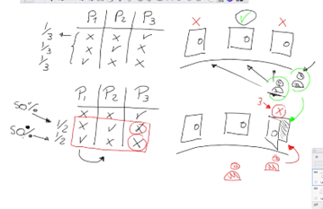

Y ese es el primer razonamiento que uno podría hacer sobre las probabilidades, entonces la paradoja es que esto es falso. Pero ¿por qué es falso? es decir ¿realmente hay mas probabilidades de ganar si yo cambio de puerta o no?

Bueno resulta que si, son situaciones distintas y cambian las probabilidades, entonces recordemos del anterior ejercicio que las probabilidades cambian de acuerdo a la información que tu posees a la hora de tomar una decisión, ¿entonces cual fue el cambio de información? fue precisamente abrir una de las puertas.

Abrir una de las puertas realmente me esta dando mayor información.

Vamos a cambiar el esquema para calcular la probabilidad, ahora añado dos columnas, para decir que me quedo con la elección y cambio de puerta. Sabiendo que la puerta que abrió el presentador.

Ahora desglosemos poco a poco.

- Escojo la puerta 1 (azul), el presentador va a abrir la puerta 2 porque el premio esta en la 3, si yo cambio de puerta gano.  
  Hagamos el mismo razonamiento con las demás.

Pero en la ultima digamos, el presentador abre la 2 y da lo mismo, si yo me quedo con la elección de la puerta 1 gano, pero si no pierdo. Entonces el espacio muestral quedaría como

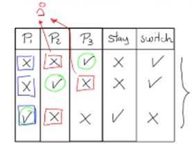

Entonces preguntémonos ¿cual es la probabilidad de ganar si yo me quedo con la puerta que elegí anteriormente?

- Claramente vemos que en los estamos anteriores solo uno me va a dar la probabilidad de victoria. $$p(win|stay)=\frac 1 3$$

Mientras que la probabilidad de ganar si yo hago un cambio (switch) a la otra puerta después de lo que hizo el presentador, ahora la probabilidad vendría descrita por los estados de switch, y en esa situación, el numero de eventos exitosos son 2, por que hay 2 eventos en lo que yo podría ganar.

$$p(win|switch)=\frac 2 3$$

### Conclusion

La probabilidad de ganar si yo hago un cambio (switch) a la otra puerta es mayor que si me quedo. Entonces así podemos ver que el calculo de probabilidades no siempre es tan intuitivo y hay que tener mucho cuidado a la hora de entender cual es el espacio muestral sobre el que estamos trabajando dado que tengamos información adicional o no sobre una cierta situación, sobre la cual queremos hacer un calculo de probabilidades.

Estos ejercicios desarrollan mucho la intuición.

Aportación de: Luis Arturo Cruz Cruz

La primera vez que escuché sobre este problema fué en la película 21 Black Jack. Aquí un enlace a la escena: https://www.youtube.com/watch?v=uz58hg0EJAY . Yo sigo un canal de matemáticas llamado Numberphile, en el siguiente link podrán ver la explicación del problema de Monthy Hall (en inglés) https://www.youtube.com/watch?v=4Lb-6rxZxx0

### Enlaces

- https://www.youtube.com/watch?v=1BpTBzDQuRE
- https://www.youtube.com/watch?v=Q5nCtgcL4jU